# Deliverable #3 - Elements that Influence Movie Ratings

Alice Wei

July 26, 2017

# **Elements that Influece Movie Ratings**

## 1. INTRODUCTION

[figure not shown]

One of the very famous films in early 1900s, [*A Trip to the Moon*](https://www.youtube.com/watch?v=zXgTFBIwDCc), opens the door of the film industry. Tons of young professionals entered the field with their dreams. From silent films to Dolby Surround Sound movies, from the simplest hand-made visual effect to computer-generated images(CGI), movie has exprienced several revolutions, and now becomes one of the most popular entertainment for people. With the blooming of the industry, the qualities of movies become mixed. Before watching the movie, audience could not really know how good it is. In this projects, I would like to use the data found from [kaggle.com](https://www.kaggle.com/) to illustarte the relationship between the rating score of the movie (the measure of the overal favorableness) and other 10 vairables, including year, box office profits, genre, etc.

By identifying the elements that influence the movie ratings,in other words, the favorableness of a movie, this analysis aims to support audiences to select films that could receive a higher rating score, and also assist them to filter out movies that would receive negtive reviews. In addition, this project is designed to benefit filmmakers, helping them to understand what are the areas that the audience cares about so that they could pay more attention in those areas while producing films.

## 2. PACKAGES

R packages used in this project include:

- Tidyverse
- dpltr
- ggplot2
- Psych
- knitr

```r
library(tidyverse)
library(knitr)
library(kableExtra)
```

## 3. DATASETS

[figure not shown]

This project utilizes the [**IMDB 5000 Movie Dataset**](https://www.kaggle.com/deepmatrix/imdb-5000-movie-dataset) on [Kaggle](https://www.kaggle.com/). The dataset, in total, contains 5,043 observations and 28 variables. Specifically, data was collected in 2016 from [IMDB](http://www.imdb.com/) website using web crawler. It contains over 5,000 movies in a wide variety of genres from 1916 to 2016.

### 3.1 Variables

```r
#Retrieve Data Variables
Variables <- names(IMDBFilmRaw)
Variables <- sort(Variables)
VariableList <- tibble(VarNum = 1:28, VarName = Variables)
#View(tibble(x =1:28,y = Variables))
kable(VariableList)
```

| VarNum | VarName |
| --- | --- |
| 1 | actor_1_facebook_likes |
| 2 | actor_1_name |
| 3 | actor_2_facebook_likes |
| 4 | actor_2_name |
| 5 | actor_3_facebook_likes |
| 6 | actor_3_name |
| 7 | aspect_ratio |
| 8 | budget |
| 9 | cast_total_facebook_likes |
| 10 | color |
| 11 | content_rating |
| 12 | country |
| 13 | director_facebook_likes |
| 14 | director_name |
| 15 | duration |
| 16 | facenumber_in_poster |
| 17 | genres |
| 18 | gross |
| 19 | imdb_score |
| 20 | language |
| 21 | movie_facebook_likes |
| 22 | movie_imdb_link |
| 23 | movie_title |
| 24 | num_critic_for_reviews |
| 25 | num_user_for_reviews |
| 26 | num_voted_users |
| 27 | plot_keywords |
| 28 | title_year |

### 3.2 Raw Dataset

```r
kable(head(IMDBFilmRaw, 15),align = 'l')
```

| color | director_name | num_critic_for_reviews | duration | director_facebook_likes | actor_3_facebook_likes | actor_2_name | actor_1_facebook_likes | gross | genres | actor_1_name | movie_title | num_voted_users | cast_total_facebook_likes | actor_3_name | facenumber_in_poster | plot_keywords | movie_imdb_link | num_user_for_reviews | language | country | content_rating | budget | title_year | actor_2_facebook_likes | imdb_score | aspect_ratio | movie_facebook_likes |
| --- | --- | --- | --- | --- | --- | --- | --- | --- | --- | --- | --- | --- | --- | --- | --- | --- | --- | --- | --- | --- | --- | --- | --- | --- | --- | --- | --- |
| Color | James Cameron | 723 | 178 | 0 | 855 | Joel David Moore | 1000 | 760505847 | Action\|Adventure\|Fantasy\|Sci-Fi | CCH Pounder | Avatar | 886204 | 4834 | Wes Studi | 0 | avatar\|future\|marine\|native\|paraplegic | http://www.imdb.com/title/tt0499549/?ref_=fn_tt_tt_1 | 3054 | English | USA | PG-13 | 237000000 | 2009 | 936 | 7.9 | 1.78 | 33000 |
| Color | Gore Verbinski | 302 | 169 | 563 | 1000 | Orlando Bloom | 40000 | 309404152 | Action\|Adventure\|Fantasy | Johnny Depp | Pirates of the Caribbean: At World’s End | 471220 | 48350 | Jack Davenport | 0 | goddess\|marriage ceremony\|marriage proposal\|pirate\|singapore | http://www.imdb.com/title/tt0449088/?ref_=fn_tt_tt_1 | 1238 | English | USA | PG-13 | 300000000 | 2007 | 5000 | 7.1 | 2.35 | 0 |
| Color | Sam Mendes | 602 | 148 | 0 | 161 | Rory Kinnear | 11000 | 200074175 | Action\|Adventure\|Thriller | Christoph Waltz | Spectre | 275868 | 11700 | Stephanie Sigman | 1 | bomb\|espionage\|sequel\|spy\|terrorist | http://www.imdb.com/title/tt2379713/?ref_=fn_tt_tt_1 | 994 | English | UK | PG-13 | 245000000 | 2015 | 393 | 6.8 | 2.35 | 85000 |
| Color | Christopher Nolan | 813 | 164 | 22000 | 23000 | Christian Bale | 27000 | 448130642 | Action\|Thriller | Tom Hardy | The Dark Knight Rises | 1144337 | 106759 | Joseph Gordon-Levitt | 0 | deception\|imprisonment\|lawlessness\|police officer\|terrorist plot | http://www.imdb.com/title/tt1345836/?ref_=fn_tt_tt_1 | 2701 | English | USA | PG-13 | 250000000 | 2012 | 23000 | 8.5 | 2.35 | 164000 |
| NA | Doug Walker | NA | NA | 131 | NA | Rob Walker | 131 | NA | Documentary | Doug Walker | Star Wars: Episode VII - The Force Awakens | 8 | 143 | NA | 0 | NA | http://www.imdb.com/title/tt5289954/?ref_=fn_tt_tt_1 | NA | NA | NA | NA | NA | NA | 12 | 7.1 | NA | 0 |
| Color | Andrew Stanton | 462 | 132 | 475 | 530 | Samantha Morton | 640 | 73058679 | Action\|Adventure\|Sci-Fi | Daryl Sabara | John Carter | 212204 | 1873 | Polly Walker | 1 | alien\|american civil war\|male nipple\|mars\|princess | http://www.imdb.com/title/tt0401729/?ref_=fn_tt_tt_1 | 738 | English | USA | PG-13 | 263700000 | 2012 | 632 | 6.6 | 2.35 | 24000 |
| Color | Sam Raimi | 392 | 156 | 0 | 4000 | James Franco | 24000 | 336530303 | Action\|Adventure\|Romance | J.K. Simmons | Spider-Man 3 | 383056 | 46055 | Kirsten Dunst | 0 | sandman\|spider man\|symbiote\|venom\|villain | http://www.imdb.com/title/tt0413300/?ref_=fn_tt_tt_1 | 1902 | English | USA | PG-13 | 258000000 | 2007 | 11000 | 6.2 | 2.35 | 0 |
| Color | Nathan Greno | 324 | 100 | 15 | 284 | Donna Murphy | 799 | 200807262 | Adventure\|Animation\|Comedy\|Family\|Fantasy\|Musical\|Romance | Brad Garrett | Tangled | 294810 | 2036 | M.C. Gainey | 1 | 17th century\|based on fairy tale\|disney\|flower\|tower | http://www.imdb.com/title/tt0398286/?ref_=fn_tt_tt_1 | 387 | English | USA | PG | 260000000 | 2010 | 553 | 7.8 | 1.85 | 29000 |
| Color | Joss Whedon | 635 | 141 | 0 | 19000 | Robert Downey Jr. | 26000 | 458991599 | Action\|Adventure\|Sci-Fi | Chris Hemsworth | Avengers: Age of Ultron | 462669 | 92000 | Scarlett Johansson | 4 | artificial intelligence\|based on comic book\|captain america\|marvel cinematic universe\|superhero | http://www.imdb.com/title/tt2395427/?ref_=fn_tt_tt_1 | 1117 | English | USA | PG-13 | 250000000 | 2015 | 21000 | 7.5 | 2.35 | 118000 |
| Color | David Yates | 375 | 153 | 282 | 10000 | Daniel Radcliffe | 25000 | 301956980 | Adventure\|Family\|Fantasy\|Mystery | Alan Rickman | Harry Potter and the Half-Blood Prince | 321795 | 58753 | Rupert Grint | 3 | blood\|book\|love\|potion\|professor | http://www.imdb.com/title/tt0417741/?ref_=fn_tt_tt_1 | 973 | English | UK | PG | 250000000 | 2009 | 11000 | 7.5 | 2.35 | 10000 |
| Color | Zack Snyder | 673 | 183 | 0 | 2000 | Lauren Cohan | 15000 | 330249062 | Action\|Adventure\|Sci-Fi | Henry Cavill | Batman v Superman: Dawn of Justice | 371639 | 24450 | Alan D. Purwin | 0 | based on comic book\|batman\|sequel to a reboot\|superhero\|superman | http://www.imdb.com/title/tt2975590/?ref_=fn_tt_tt_1 | 3018 | English | USA | PG-13 | 250000000 | 2016 | 4000 | 6.9 | 2.35 | 197000 |
| Color | Bryan Singer | 434 | 169 | 0 | 903 | Marlon Brando | 18000 | 200069408 | Action\|Adventure\|Sci-Fi | Kevin Spacey | Superman Returns | 240396 | 29991 | Frank Langella | 0 | crystal\|epic\|lex luthor\|lois lane\|return to earth | http://www.imdb.com/title/tt0348150/?ref_=fn_tt_tt_1 | 2367 | English | USA | PG-13 | 209000000 | 2006 | 10000 | 6.1 | 2.35 | 0 |
| Color | Marc Forster | 403 | 106 | 395 | 393 | Mathieu Amalric | 451 | 168368427 | Action\|Adventure | Giancarlo Giannini | Quantum of Solace | 330784 | 2023 | Rory Kinnear | 1 | action hero\|attempted rape\|bond girl\|official james bond series\|revenge | http://www.imdb.com/title/tt0830515/?ref_=fn_tt_tt_1 | 1243 | English | UK | PG-13 | 200000000 | 2008 | 412 | 6.7 | 2.35 | 0 |
| Color | Gore Verbinski | 313 | 151 | 563 | 1000 | Orlando Bloom | 40000 | 423032628 | Action\|Adventure\|Fantasy | Johnny Depp | Pirates of the Caribbean: Dead Man’s Chest | 522040 | 48486 | Jack Davenport | 2 | box office hit\|giant squid\|heart\|liar’s dice\|monster | http://www.imdb.com/title/tt0383574/?ref_=fn_tt_tt_1 | 1832 | English | USA | PG-13 | 225000000 | 2006 | 5000 | 7.3 | 2.35 | 5000 |
| Color | Gore Verbinski | 450 | 150 | 563 | 1000 | Ruth Wilson | 40000 | 89289910 | Action\|Adventure\|Western | Johnny Depp | The Lone Ranger | 181792 | 45757 | Tom Wilkinson | 1 | horse\|outlaw\|texas\|texas ranger\|train | http://www.imdb.com/title/tt1210819/?ref_=fn_tt_tt_1 | 711 | English | USA | PG-13 | 215000000 | 2013 | 2000 | 6.5 | 2.35 | 48000 |

## 4. DATA PREPARATION

```r
#Select and reorder columns
CleanFilmData <- IMDBFilmRaw[,c(12,26,4,1,24,10,20,9,23,5,6,8,25,28)]

#Remove NA, Sepreate Column and get first element, add new variable)
FinalFilmData <- CleanFilmData %>%
  na.omit() %>%
  separate(genres, into = c("Genre_1")) %>%
  mutate(TotalFacebooklikes = actor_3_facebook_likes + actor_2_facebook_likes +
           actor_1_facebook_likes + director_facebook_likes +
           movie_facebook_likes) %>%
  mutate(ProfitTurnover = (gross - budget) / budget)

# remove summed columns
FinalFilmData <- FinalFilmData[,-c(10:14)]
```

### 4.1 Variables

```r
#Retrieve New Var Names
FinalVar <- names(FinalFilmData)
VarType <- lapply(FinalFilmData, typeof)
FinalVarList <- tibble(Num = 1:11, VarName = FinalVar, Type = VarType)
kable(FinalVarList)
```

| Num | VarName | Type |
| --- | --- | --- |
| 1 | movie_title | character |
| 2 | imdb_score | double |
| 3 | duration | integer |
| 4 | color | character |
| 5 | title_year | integer |
| 6 | Genre_1 | character |
| 7 | language | character |
| 8 | gross | integer |
| 9 | budget | integer |
| 10 | TotalFacebooklikes | integer |
| 11 | ProfitTurnover | double |

### 4.2 Raw Dataset

```r
kable(head(FinalFilmData,15))
```

| movie_title | imdb_score | duration | color | title_year | Genre_1 | language | gross | budget | TotalFacebooklikes | ProfitTurnover |
| --- | --- | --- | --- | --- | --- | --- | --- | --- | --- | --- |
| Avatar | 7.9 | 178 | Color | 2009 | Action | English | 760505847 | 237000000 | 35791 | 2.2088854 |
| Pirates of the Caribbean: At World’s End | 7.1 | 169 | Color | 2007 | Action | English | 309404152 | 300000000 | 46563 | 0.0313472 |
| Spectre | 6.8 | 148 | Color | 2015 | Action | English | 200074175 | 245000000 | 96554 | -0.1833707 |
| The Dark Knight Rises | 8.5 | 164 | Color | 2012 | Action | English | 448130642 | 250000000 | 259000 | 0.7925226 |
| John Carter | 6.6 | 132 | Color | 2012 | Action | English | 73058679 | 263700000 | 26277 | -0.7229477 |
| Spider-Man 3 | 6.2 | 156 | Color | 2007 | Action | English | 336530303 | 258000000 | 39000 | 0.3043810 |
| Tangled | 7.8 | 100 | Color | 2010 | Adventure | English | 200807262 | 260000000 | 30651 | -0.2276644 |
| Avengers: Age of Ultron | 7.5 | 141 | Color | 2015 | Action | English | 458991599 | 250000000 | 184000 | 0.8359664 |
| Harry Potter and the Half-Blood Prince | 7.5 | 153 | Color | 2009 | Adventure | English | 301956980 | 250000000 | 56282 | 0.2078279 |
| Batman v Superman: Dawn of Justice | 6.9 | 183 | Color | 2016 | Action | English | 330249062 | 250000000 | 218000 | 0.3209962 |
| Superman Returns | 6.1 | 169 | Color | 2006 | Action | English | 200069408 | 209000000 | 28903 | -0.0427301 |
| Quantum of Solace | 6.7 | 106 | Color | 2008 | Action | English | 168368427 | 200000000 | 1651 | -0.1581579 |
| Pirates of the Caribbean: Dead Man’s Chest | 7.3 | 151 | Color | 2006 | Action | English | 423032628 | 225000000 | 51563 | 0.8801450 |
| The Lone Ranger | 6.5 | 150 | Color | 2013 | Action | English | 89289910 | 215000000 | 91563 | -0.5846981 |
| Man of Steel | 7.2 | 143 | Color | 2013 | Action | English | 291021565 | 225000000 | 136748 | 0.2934292 |

## 5. METHODOLOGY

In this project, I aim to use several stastical methods to demostrate the relationship. I would like to investigate the distribution of rating score and create histogram to visualize the distribution. Also, I plan to plot box plots and scattered graphs to compare and contrast the data.

To further analyze the relationship and the reliability of the relationship, I would like to run a regression, examing the change of the rating score of a movie when 10 other factors are varied.

- Dependent Variable: **IMDB Rating Score**
- Independent Variable:
  1. Color - Catagorical (Dummy)
  2. Duration - Quantitative
  3. Box Office Profits - Quantitative
  4. Genres - Catagorical
  5. Length of Movie Title - Quantitative
  6. Number of User for reviews - Quantitative
  7. Language - Catagorical
  8. Budget - Quantitative
  9. Title Year - Catagorical
  10. Number of Movie Facebook Likes - Quantitative

## 6. DATA ANALYSIS

### 6.1 Observations (TOP 10 LISTS)

**6.1.1 Top 10 rating**

```r
FinalFilmData %>% arrange(desc(imdb_score)) %>% head(10) %>% kable()
```

| movie_title | imdb_score | duration | color | title_year | Genre_1 | language | gross | budget | TotalFacebooklikes | ProfitTurnover |
| --- | --- | --- | --- | --- | --- | --- | --- | --- | --- | --- |
| The Shawshank Redemption | 9.3 | 142 | Color | 1994 | Crime | English | 28341469 | 2.50e+07 | 120206 | 0.1336588 |
| The Godfather | 9.2 | 175 | Color | 1972 | Crime | English | 134821952 | 6.00e+06 | 70000 | 21.4703253 |
| The Dark Knight | 9.0 | 152 | Color | 2008 | Action | English | 533316061 | 1.85e+08 | 106000 | 1.8827895 |
| The Godfather: Part II | 9.0 | 220 | Color | 1974 | Crime | English | 57300000 | 1.30e+07 | 53000 | 3.4076923 |
| The Lord of the Rings: The Return of the King | 8.9 | 192 | Color | 2003 | Action | English | 377019252 | 9.40e+07 | 22273 | 3.0108431 |
| Schindler’s List | 8.9 | 185 | Black and White | 1993 | Biography | English | 96067179 | 2.20e+07 | 70007 | 3.3666900 |
| Pulp Fiction | 8.9 | 178 | Color | 1994 | Crime | English | 107930000 | 8.00e+06 | 75759 | 12.4912500 |
| The Good, the Bad and the Ugly | 8.9 | 142 | Color | 1966 | Western | Italian | 6100000 | 1.20e+06 | 36058 | 4.0833333 |
| Inception | 8.8 | 148 | Color | 2010 | Action | English | 292568851 | 1.60e+08 | 276000 | 0.8285553 |
| The Lord of the Rings: The Fellowship of the Ring | 8.8 | 171 | Color | 2001 | Action | English | 313837577 | 9.30e+07 | 42857 | 2.3745976 |

```r
FinalFilmData %>% arrange(desc(gross)) %>% head(10) %>% kable()
```

| movie_title | imdb_score | duration | color | title_year | Genre_1 | language | gross | budget | TotalFacebooklikes | ProfitTurnover |
| --- | --- | --- | --- | --- | --- | --- | --- | --- | --- | --- |
| Avatar | 7.9 | 178 | Color | 2009 | Action | English | 760505847 | 2.37e+08 | 35791 | 2.2088854 |
| Titanic | 7.7 | 194 | Color | 1997 | Drama | English | 658672302 | 2.00e+08 | 69794 | 2.2933615 |
| Jurassic World | 7.0 | 124 | Color | 2015 | Action | English | 652177271 | 1.50e+08 | 156365 | 3.3478485 |
| The Avengers | 8.1 | 173 | Color | 2012 | Action | English | 623279547 | 2.20e+08 | 189000 | 1.8330888 |
| The Avengers | 8.1 | 173 | Color | 2012 | Action | English | 623279547 | 2.20e+08 | 189000 | 1.8330888 |
| The Dark Knight | 9.0 | 152 | Color | 2008 | Action | English | 533316061 | 1.85e+08 | 106000 | 1.8827895 |
| Star Wars: Episode I - The Phantom Menace | 6.5 | 136 | Color | 1999 | Action | English | 474544677 | 1.15e+08 | 48000 | 3.1264755 |
| Star Wars: Episode IV - A New Hope | 8.7 | 125 | Color | 1977 | Action | English | 460935665 | 1.10e+07 | 45504 | 40.9032423 |
| Avengers: Age of Ultron | 7.5 | 141 | Color | 2015 | Action | English | 458991599 | 2.50e+08 | 184000 | 0.8359664 |
| The Dark Knight Rises | 8.5 | 164 | Color | 2012 | Action | English | 448130642 | 2.50e+08 | 259000 | 0.7925226 |

**6.1.3 Top 10 Profit Turnover**

```r
FinalFilmData %>% arrange(desc(ProfitTurnover)) %>% head(10) %>% kable()
```

| movie_title | imdb_score | duration | color | title_year | Genre_1 | language | gross | budget | TotalFacebooklikes | ProfitTurnover |
| --- | --- | --- | --- | --- | --- | --- | --- | --- | --- | --- |
| Paranormal Activity | 6.3 | 84 | Color | 2007 | Horror | English | 107917283 | 15000 | 12429 | 7193.4855 |
| Tarnation | 7.2 | 88 | Color | 2003 | Biography | English | 592014 | 218 | 852 | 2714.6606 |
| The Blair Witch Project | 6.4 | 81 | Black and White | 1999 | Horror | English | 140530114 | 60000 | 398 | 2341.1686 |
| The Brothers McMullen | 6.6 | 98 | Color | 1995 | Comedy | English | 10246600 | 25000 | 587 | 408.8640 |
| The Texas Chain Saw Massacre | 7.5 | 88 | Color | 1974 | Horror | English | 30859000 | 83532 | 1296 | 368.4273 |
| The Texas Chain Saw Massacre | 7.5 | 88 | Color | 1974 | Horror | English | 30859000 | 83532 | 1296 | 368.4273 |
| El Mariachi | 6.9 | 81 | Color | 1992 | Action | Spanish | 2040920 | 7000 | 147 | 290.5600 |
| The Gallows | 4.2 | 81 | Color | 2015 | Horror | English | 22757819 | 100000 | 270 | 226.5782 |
| Super Size Me | 7.3 | 100 | Color | 2004 | Comedy | English | 11529368 | 65000 | 293 | 176.3749 |
| Halloween | 7.9 | 101 | Color | 1978 | Horror | English | 47000000 | 300000 | 15340 | 155.6667 |

### 6.2 Summary Statistics

**6.2.1 Basic Summary**

```r
# Data Summary
kable(do.call(cbind, lapply(FinalFilmData, summary)))
```

|  | movie_title | imdb_score | duration | color | title_year | Genre_1 | language | gross | budget | TotalFacebooklikes | ProfitTurnover |
| --- | --- | --- | --- | --- | --- | --- | --- | --- | --- | --- | --- |
| Min. | 3871 | 1.6 | 34 | 3871 | 1927 | 3871 | 3871 | 162 | 218 | 28 | -0.999982 |
| 1st Qu. | character | 5.9 | 95 | character | 1999 | character | character | 7001987.5 | 1e+07 | 2056.5 | -0.544660827990431 |
| Median | character | 6.6 | 106 | character | 2005 | character | character | 28399192 | 2.4e+07 | 9541 | 0.07515297 |
| Mean | 3871 | 6.46150865409455 | 109.947558770344 | 3871 | 2003.11159907001 | 3871 | 3871 | 51269181.8194265 | 39860314.074141 | 20292.6850942909 | 5.26806175859224 |
| 3rd Qu. | character | 7.2 | 120 | character | 2010 | character | character | 65546528 | 5e+07 | 26280.5 | 1.2301541875 |
| Max. | character | 9.3 | 330 | character | 2016 | character | character | 760505847 | 2127519898 | 655285 | 7193.48553333333 |

**6.2.2 Distribution**

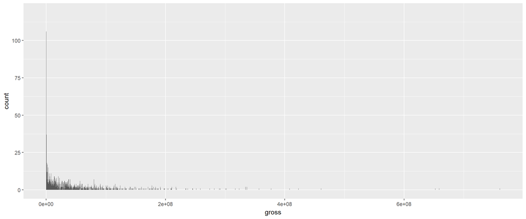

```r
FinalFilmData %>% ggplot(aes(gross)) + geom_histogram(binwidth = 100000)
```

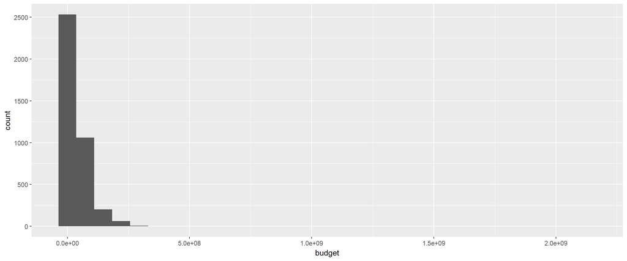

```r
FinalFilmData %>% ggplot(aes(budget)) + geom_histogram()
```

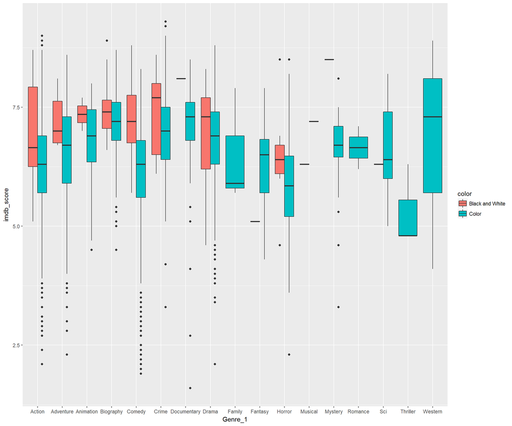

```r
FinalFilmData %>%
  ggplot(aes(y=imdb_score, x = Genre_1, categoty = color, fill = color)) +
  geom_boxplot()
```